# GSE2658 spectra analysis prodvers 20220711

```r
library(readr)
library(dplyr)
library(tidyr)
library(survival)
library(ggplot2)
library(ggsci)
library(mclust)
library(survminer)
library(cowplot)
```

## load data

### rotation matrix

```r
rotation_matrix <- read_csv("~/Documents/stats/survival/commpass_proj/spectra_commpass_product/CoMMpass_inclfollowup_final_SpectraData_20210601/spectra_rotation_matrix-gene_centers-2021-06-01.csv")
```

### expression values

```r
exp_cbat <- read_csv("~/Documents/stats/survival/commpass_proj/spectra_commpass_product/gse2658_exprs_adj_withzeros_survd_20220518.csv")
```

## applying loadings to expression data

### matrix prep

expression is long format, need in wide and to remove extra cols  
then make matrix and transpose (want genes in cols and people in rows)

```r
exp_cbat_wide_t <- exp_cbat %>%
  arrange(gene_id) %>%
  select(gene_id, sample_id, adjlogcpkmed) %>%
  pivot_wider(names_from = sample_id, values_from = adjlogcpkmed) %>%
  tibble::column_to_rownames("gene_id") %>%
  as.matrix() %>%
  t()
```

just to make sure gene ids in same order in both datasets

```r
exp_cbat %>% distinct(gene_id) %>% dim()
```

```
[1] 7449    1
```

```r
rotation_matrix %>% distinct(gene_id) %>% dim()
```

```
[1] 7449    1
```

```r
sum(rotation_matrix$gene_id==colnames(exp_cbat_wide_t))
```

```
[1] 7449
```

7449 is number of genes in both, so that’s good.

center expression values using means from *this microarray expression* set  
do *not* scale the values

```r
exp_cbat_means <- exp_cbat %>% group_by(gene_id) %>% summarise(mean_exp=mean(adjlogcpkmed))
```

```r
exp_cbat_wide_t_scaled <- scale(exp_cbat_wide_t, center=exp_cbat_means$mean_exp, scale=F)
```

just double check that these are all “zero” (`1e-15`)

```r
sum(colMeans(exp_cbat_wide_t_scaled)<1e-15)
```

```
[1] 7449
```

seems good

get rotation matrix ready for multiplication

```r
rotation_matrix2 <- rotation_matrix %>%
  select(-mean) %>%
  tibble::column_to_rownames("gene_id") %>%
  as.matrix()
```

### matrix muiltiplication

using micro array mean centering

```r
calc_gse2658_spectra_mam <- exp_cbat_wide_t_scaled %*% rotation_matrix2
```

### scaling

We need to scale these by SD of baseline spectra, it’s easiest to get the SDs from the PCA details from the derivation process

```r
commpass_pcadets <- read_csv("~/Documents/stats/survival/commpass_proj/spectra_commpass_product/CoMMpass_inclfollowup_final_SpectraData_20210601/pca_details-2021-06-01.csv")
```

```r
cmps_spsd2 <- sqrt(commpass_pcadets$value)[1:39]
cmps_spsd2
```

```
 [1] 16.581274 15.129598 12.826140 11.122506 10.987019  9.706932  9.225481  8.685543  8.387991  7.747727
[11]  7.271445  7.168792  6.549592  6.342254  6.200449  5.838001  5.737788  5.556130  5.403236  5.158895
[21]  5.141832  5.033840  4.904114  4.813666  4.792301  4.544934  4.525382  4.411011  4.327242  4.181055
[31]  4.140743  4.096505  4.067145  3.971407  3.866027  3.805389  3.752735  3.725545  3.574375
```

before:

```r
calc_gse2658_spectra_mam[1:5,1:5]
```

```
                 PC1        PC2         PC3         PC4        PC5
GSM102606  14.727098  -5.123928 -14.9390537   0.8170376   6.899278
GSM102607  10.272769 -12.312540  -7.3301641   5.2259364   5.143442
GSM102609  -4.849132 -20.584901   8.9558609   3.5520598  -7.043210
GSM102610   1.257738   5.584896   6.2828234 -13.1929729 -13.735265
GSM102611 -10.372680  18.788593  -0.4368836  -2.9918273  -5.420794
```

use `scale` to divide by CoMMpass scores SD

```r
calc_gse2658_spectra_mam_sd <- scale(calc_gse2658_spectra_mam, center=F, scale = as.numeric(cmps_spsd2))
```

```r
calc_gse2658_spectra_mam_sd[1:5,1:5]
```

```
                  PC1        PC2         PC3         PC4        PC5
GSM102606  0.88817653 -0.3386692 -1.16473493  0.07345805  0.6279482
GSM102607  0.61954042 -0.8138049 -0.57150194  0.46985242  0.4681381
GSM102609 -0.29244629 -1.3605716  0.69825065  0.31935787 -0.6410484
GSM102610  0.07585292  0.3691371  0.48984521 -1.18615112 -1.2501358
GSM102611 -0.62556592  1.2418435 -0.03406197 -0.26898860 -0.4933817
```

### join survival data to scores

```r
calc_gse2658_spectra_mam_sd <- calc_gse2658_spectra_mam_sd %>%
  as.data.frame() %>%
  tibble::rownames_to_column(var="sample_id")
colnames(calc_gse2658_spectra_mam_sd) <- c("sample_id", paste0("Sp",1:39))
```

```r
calc_gse2658_spectra_mam_sd <- left_join(calc_gse2658_spectra_mam_sd,
                                     exp_cbat %>% distinct(sample_id, censos, ttcos),
                                     by="sample_id") %>%
  relocate(censos, ttcos, .after="sample_id")
```

clean up

```r
rm(list=c("exp_cbat_wide_t", "exp_cbat"))
```

## using GMM threshold from CoMMpass modeling on GSE2658 data

GSE2658 risk score derived using CoMMpass betas, then use GMM threshold from CoMMpass GMM model (*NOT* doing any GMM on GSE2658 data)

### GMM on CoMMpass data to get threshold

bring in baseline CoMMpass spectra (scaled by SD) and survival outcome

```r
commpass_os <- read_csv("./commpass_spectra_baseline_os_20210601.csv")
cmps_os <- commpass_os %>% dplyr::select(ttcos, censos, Sp1:Sp39)
```

make Cox model with CoMMpass data:

```r
commpass_os_sigp_cox <-
  coxph(Surv(ttcos, censos) ~ Sp2 + Sp3 + Sp4 + Sp5 + Sp9 + Sp12 + Sp13 + Sp19 + Sp26,
        data=cmps_os)
summary(commpass_os_sigp_cox)
```

```
Call:
coxph(formula = Surv(ttcos, censos) ~ Sp2 + Sp3 + Sp4 + Sp5 +
    Sp9 + Sp12 + Sp13 + Sp19 + Sp26, data = cmps_os)

  n= 767, number of events= 179

         coef exp(coef) se(coef)      z Pr(>|z|)
Sp2  -0.33508   0.71528  0.07612 -4.402 1.07e-05 ***
Sp3   0.24299   1.27506  0.07530  3.227  0.00125 **
Sp4   0.46078   1.58532  0.06837  6.740 1.59e-11 ***
Sp5  -0.32418   0.72312  0.07453 -4.349 1.37e-05 ***
Sp9  -0.33495   0.71537  0.07259 -4.614 3.95e-06 ***
Sp12 -0.17886   0.83623  0.07055 -2.535  0.01124 *
Sp13  0.17373   1.18974  0.07635  2.276  0.02287 *
Sp19  0.11113   1.11754  0.06902  1.610  0.10736
Sp26  0.18376   1.20173  0.07776  2.363  0.01812 *
---
Signif. codes:  0 ‘***’ 0.001 ‘**’ 0.01 ‘*’ 0.05 ‘.’ 0.1 ‘ ’ 1

     exp(coef) exp(-coef) lower .95 upper .95
Sp2     0.7153     1.3980    0.6161    0.8304
Sp3     1.2751     0.7843    1.1001    1.4778
Sp4     1.5853     0.6308    1.3865    1.8126
Sp5     0.7231     1.3829    0.6248    0.8369
Sp9     0.7154     1.3979    0.6205    0.8248
Sp12    0.8362     1.1958    0.7282    0.9602
Sp13    1.1897     0.8405    1.0244    1.3818
Sp19    1.1175     0.8948    0.9761    1.2794
Sp26    1.2017     0.8321    1.0319    1.3996

Concordance= 0.701  (se = 0.023 )
Likelihood ratio test= 127.7  on 9 df,   p=<2e-16
Wald test            = 143.8  on 9 df,   p=<2e-16
Score (logrank) test = 145  on 9 df,   p=<2e-16
```

```r
cmps_rset_data <- data.frame(sample_id=commpass_os$sample_id,
                                    ttcos=commpass_os$ttcos,
                                    years=commpass_os$ttcos/12,
                                    months=commpass_os$ttcos/(365/12),
                                    censos=commpass_os$censos,
                                    cmps_lp=commpass_os_sigp_cox$linear.predictors)
```

```r
cmps_data_fit <- densityMclust(cmps_rset_data$cmps_lp, G=2, modelNames="E", verbose=F, plot = F)
cmps_rset_data$cl_gmm2 <- cmps_data_fit$classification
gmm2_means <- data.frame(means=cmps_data_fit$parameters$mean)
cmps_rset_data$gmm2_class <- ifelse(cmps_rset_data$cl_gmm2==2, "high", "low")
cmps_rset_data$gmm2_class <- factor(cmps_rset_data$gmm2_class, levels=c("low", "high"))
```

```r
gmm2E_cmps_cdens <- predict(cmps_data_fit, what="cdens")
gmm2E_cmps_pldata <- data.frame(x=cmps_data_fit$data, y=cmps_data_fit$density,
                               class=as.factor(cmps_data_fit$classification),
                               cdens1=gmm2E_cmps_cdens[,1],
                               cdens2=gmm2E_cmps_cdens[,2])
```

```r
gmm2e_plot <- ggplot(gmm2E_cmps_pldata) +
  geom_histogram(aes(x, y=..density..), binwidth=0.05, position="identity", fill="grey75") +
  #geom_line(aes(x=x, y=y), color="grey20", size=1) +
  geom_line(aes(x=x, y=cdens1*cmps_data_fit$parameters$pro[1]), color="#1F77B4FF", size=1) +
  geom_line(aes(x=x, y=cdens2*cmps_data_fit$parameters$pro[2]), color="#FF7F0EFF", size=1) +
  geom_rug(aes(x=x, color=class)) + scale_color_d3(labels = c("low", "high")) +
  theme_minimal() + theme(axis.text.y = element_blank(), panel.grid=element_blank()) +
  scale_x_continuous(breaks=seq(-3,3,by=1)) +
  coord_cartesian(xlim=c(-2.5,3.6)) +
  theme(legend.position = c(0.9, 0.8)) +
  labs(x="OS spectra score", color="risk group", y="")
```

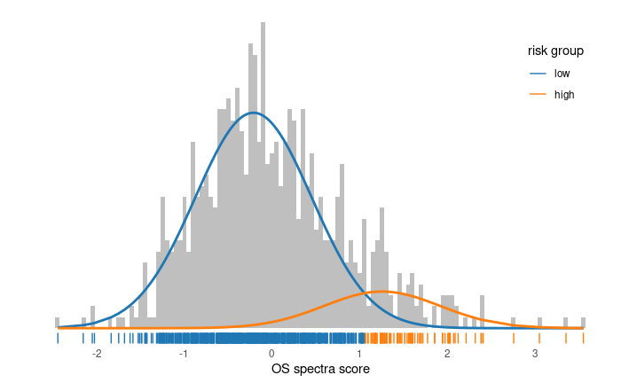

```r
gmm2e_plot
```

GMM threshold

```r
cmps_gmm_thresh <-
  (gmm2E_cmps_pldata %>% arrange(x) %>% filter(class==2) %>% slice_head() %>% pull(x) +
  gmm2E_cmps_pldata %>% arrange(x) %>% filter(class==1) %>% slice_tail() %>% pull(x))/2
cmps_gmm_thresh
```

```
[1] 1.052535
```

actuarial HR for CoMMpass data

actuarial hazard function

```r
act.haz.se <- function(data, time, event, class){
  data <- as.data.frame(data)
  time <- data[,time]
  event <- data[,event]
  class <- data[,class]
  temp_sdf <- survdiff(Surv(time, event) ~ class)
  HR <- (temp_sdf$obs[2]/temp_sdf$exp[2])/(temp_sdf$obs[1]/temp_sdf$exp[1])
  SE <- sqrt(1/temp_sdf$exp[1] + 1/temp_sdf$exp[2])
  CIL <- exp(log(HR)-(1.96*SE))
  CIU <- exp(log(HR)+(1.96*SE))
  return(c(hr=HR,se.ln.hr=SE,conf.low=CIL,conf.up=CIU))
}
```

```r
gmm2_cmps_thr_HR <- act.haz.se(cmps_rset_data, "ttcos", "censos", "gmm2_class")
gmm2_cmps_thr_HR
```

```
        hr   se.ln.hr   conf.low    conf.up
 6.4380445  0.2943181  3.6159742 11.4625867
```

HR from Cox model for CoMMpass data

```r
summary(coxph(Surv(ttcos, censos)~gmm2_class, data=cmps_rset_data))
```

```
Call:
coxph(formula = Surv(ttcos, censos) ~ gmm2_class, data = cmps_rset_data)

  n= 767, number of events= 179

                 coef exp(coef) se(coef)     z Pr(>|z|)
gmm2_classhigh 1.9088    6.7451   0.1631 11.71   <2e-16 ***
---
Signif. codes:  0 ‘***’ 0.001 ‘**’ 0.01 ‘*’ 0.05 ‘.’ 0.1 ‘ ’ 1

               exp(coef) exp(-coef) lower .95 upper .95
gmm2_classhigh     6.745     0.1483       4.9     9.285

Concordance= 0.638  (se = 0.017 )
Likelihood ratio test= 103.6  on 1 df,   p=<2e-16
Wald test            = 137  on 1 df,   p=<2e-16
Score (logrank) test = 182.2  on 1 df,   p=<2e-16
```

### risk score for GSE2658 using CoMMpass betas

predict risk score for GSE2658 using model above

```r
calc_gse2658_sp_cmps_mod <- calc_gse2658_spectra_mam_sd %>%
  select(contains("Sp", ignore.case = F))
calc_gse2658_sp_cmps_mod$cmps_b_lp <-
  predict(commpass_os_sigp_cox, newdata = calc_gse2658_sp_cmps_mod)
```

### classifying GSE2658 with CoMMpass GMM threshold

threshold from CoMMpass data

```r
cmps_gmm_thresh
```

```
[1] 1.052535
```

using threshold to bin H/L groups using the microarray centered CoMMpass beta predicted linear predictor

```r
gse2658_cmpsb_rset_data <- data.frame(sample_id=calc_gse2658_spectra_mam_sd$sample_id,
                                    ttcos=calc_gse2658_spectra_mam_sd$ttcos,
                                    years=calc_gse2658_spectra_mam_sd$ttcos/12,
                                    censos=calc_gse2658_spectra_mam_sd$censos,
                                    cmps_b_lp=calc_gse2658_sp_cmps_mod$cmps_b_lp)
```

```r
gse2658_cmpsb_rset_data <- gse2658_cmpsb_rset_data %>%
  mutate(cmps_thresh_cl=case_when(cmps_b_lp>=cmps_gmm_thresh ~ "high",
                                  cmps_b_lp<cmps_gmm_thresh ~ "low"))
head(gse2658_cmpsb_rset_data,10)
```

|  | sample_id | ttcos | years | censos | cmps_b_lp | cmps_thresh_cl |
| --- | --- | --- | --- | --- | --- | --- |
| 1 | GSM102606 | 1.37 | 0.1141667 | 0 | -0.3114059 | low |
| 2 | GSM102607 | 9.03 | 0.7525000 | 0 | 0.5657541 | low |
| 3 | GSM102609 | 7.23 | 0.6025000 | 0 | 1.7020587 | high |
| 4 | GSM102610 | 6.93 | 0.5775000 | 0 | 0.1163755 | low |
| 5 | GSM102611 | 6.97 | 0.5808333 | 0 | -0.6697865 | low |
| 6 | GSM102612 | 6.93 | 0.5775000 | 0 | -1.0122398 | low |
| 7 | GSM102613 | 6.60 | 0.5500000 | 0 | 0.1242133 | low |
| 8 | GSM102614 | 6.37 | 0.5308333 | 0 | 0.2245252 | low |
| 9 | GSM102615 | 6.30 | 0.5250000 | 0 | 1.9577357 | high |
| 10 | GSM102616 | 6.30 | 0.5250000 | 0 | -0.5042312 | low |

```r
gse2658_cmpsb_rset_data$cmps_thresh_cl <- factor(gse2658_cmpsb_rset_data$cmps_thresh_cl,
                                                 levels = c("low","high"))
```

actuarial HR

```r
cmps_thr_HR <- act.haz.se(gse2658_cmpsb_rset_data, "ttcos", "censos", "cmps_thresh_cl")
cmps_thr_HR
```

```
        hr   se.ln.hr   conf.low    conf.up
 4.4343782  0.4449033  1.8540585 10.6057655
```

HR from Cox model

```r
summary(cmps_thr_coxsum <- coxph(Surv(ttcos, censos)~cmps_thresh_cl, data=gse2658_cmpsb_rset_data))
```

```
Call:
coxph(formula = Surv(ttcos, censos) ~ cmps_thresh_cl, data = gse2658_cmpsb_rset_data)

  n= 559, number of events= 100

                     coef exp(coef) se(coef)     z Pr(>|z|)
cmps_thresh_clhigh 1.5048    4.5033   0.2521 5.969 2.39e-09 ***
---
Signif. codes:  0 ‘***’ 0.001 ‘**’ 0.01 ‘*’ 0.05 ‘.’ 0.1 ‘ ’ 1

                   exp(coef) exp(-coef) lower .95 upper .95
cmps_thresh_clhigh     4.503     0.2221     2.747     7.382

Concordance= 0.596  (se = 0.023 )
Likelihood ratio test= 26.14  on 1 df,   p=3e-07
Wald test            = 35.62  on 1 df,   p=2e-09
Score (logrank) test = 42.78  on 1 df,   p=6e-11
```

GSE2658 risk score histogram on same scale as CoMMpass histo

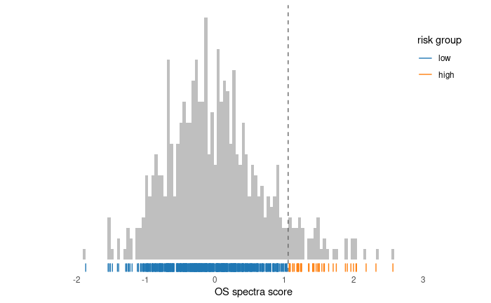

```r
gse2658_srs_histo <-
  ggplot(gse2658_cmpsb_rset_data) +
  geom_histogram(aes(cmps_b_lp, y=..density..), binwidth=0.045, position="identity", fill="grey75") +
  geom_vline(xintercept=cmps_gmm_thresh, color="grey40", linetype="dashed") +
  geom_rug(aes(x=cmps_b_lp, color=cmps_thresh_cl)) + scale_color_d3(labels = c("low", "high")) +
  theme_minimal() + theme(axis.text.y = element_blank(), panel.grid=element_blank()) +
  scale_x_continuous(breaks=seq(-3,3,by=1)) +
  coord_cartesian(xlim=c(-2.5,3.6)) +
  theme(legend.position = c(0.9, 0.8)) +
  labs(x="OS spectra score", color="risk group", y="")
gse2658_srs_histo
```

## survival analysis

survival indicator from GSE2658, info from data from GEO file  
variable name: `characteristics_ch1`  
info: `(Indicator of disease-related death; integer, 0=alive or death by other cause, 1=disease related death, na=death cause undetermined)` and  
`description.3` variable says:  
`GSM50986 Disease-related survival: Deaths were coded as disease-related according to a physician chart review. Three deaths had not been coded as of the time of the analysis and these corresponding to the three missing status indicators in the data set. Non-disease related deaths are competing risks, so distribution estimates should use cumulative incidence of disease-related death as the outcome, rather than survival`  
`description.4` variable says:  
`GSM50986 Censored data analysis: Analyses using the status indicator as a grouping variable directly are not recommended. Tests for censored data can be applied, gene-by-gene, as in the published analysis, or disease-related deaths can be matched to a random sample of longer survivors`

total number of events

```r
table(gse2658_cmpsb_rset_data$censos)
```

```
  0   1
459 100
```

there are 100 events in 559 people

### survival curves

#### GSE2658

```r
nhigh_ct <- table(gse2658_cmpsb_rset_data$cmps_thresh_cl)[2]
nevent_ct <- gse2658_cmpsb_rset_data %>%
  filter(cmps_thresh_cl=="high") %>%
  dplyr::summarize(events=sum(censos)) %>%
  pull(events)
data.frame(cat=c("people in high group","events in high group"), n=c(unname(nhigh_ct), nevent_ct))
```

| cat | n |
| --- | --- |
| people in high group | 43 |
| events in high group | 20 |

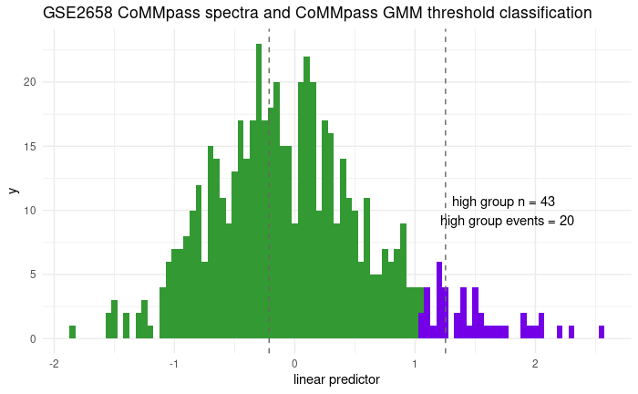

```r
ggplot(gse2658_cmpsb_rset_data) + geom_histogram(aes(cmps_b_lp), binwidth=0.05, fill="#339933") +
  geom_histogram(data=gse2658_cmpsb_rset_data %>% filter(cmps_thresh_cl=="high"),
                 aes(cmps_b_lp), binwidth=0.05, fill="#7300e6") +
  geom_vline(data=gmm2_means, aes(xintercept=means), color="grey40", linetype="dashed") +
  annotate("text", x=1.75, y=10,
           label=paste("high group n =", nhigh_ct, "\n", "high group events =", nevent_ct)) +
  theme_minimal() +
  labs(x="linear predictor",
       title="GSE2658 CoMMpass spectra and CoMMpass GMM threshold classification")
```

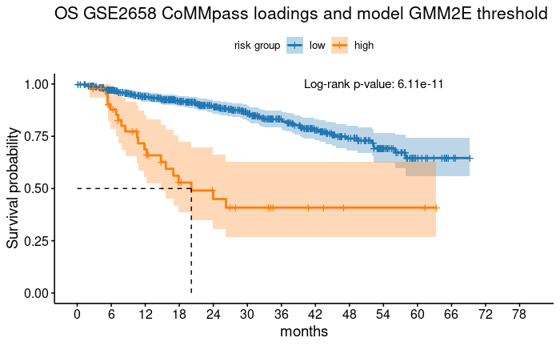

```r
gse2658_cb_cthresh_svf <- survfit(Surv(ttcos, censos)~cmps_thresh_cl, data=gse2658_cmpsb_rset_data)
pval_ct <- broom::glance(survdiff(Surv(ttcos, censos)~cmps_thresh_cl, data=gse2658_cmpsb_rset_data))$p.value
gse2658_cb_cthresh_kmplt <- ggsurvplot(gse2658_cb_cthresh_svf, surv.median.line="hv",
                                 conf.int=T, break.time.by=6,
           pval=paste0("Log-rank p-value: ", formatC(pval_ct, format = "e", digits = 2)),
           pval.size=4, pval.coord=c(40,1),
           palette=c("#1F77B4FF","#FF7F0EFF"),
           legend.title = "risk group", legend.labs = c("low", "high")) +
  labs(x="months", title="OS GSE2658 CoMMpass loadings and model GMM2E threshold")
gse2658_cb_cthresh_kmplt
```

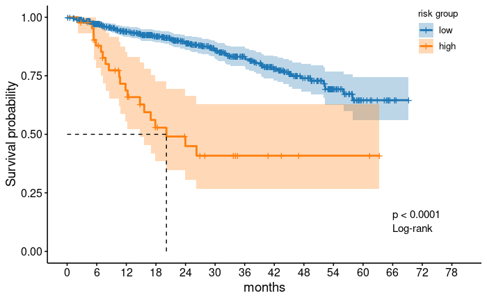

```r
gse2658_cb_cthresh_kmplt <-
  ggsurvplot(gse2658_cb_cthresh_svf, surv.median.line="hv", conf.int=T, break.time.by=6,
                      pval=T, pval.method=T,
                      pval.size=4, pval.coord=c(66,0.16),
                      pval.method.coord=c(66,0.10),
                      palette=c("#1F77B4FF","#FF7F0EFF"), legend=c(0.9,0.9),# legend="top",
                      legend.title = "risk group", legend.labs = c("low", "high")) +
  labs(x="months")
gse2658_cb_cthresh_kmplt
```

```r
gse2658_cb_cthresh_svf
```

```
Call: survfit(formula = Surv(ttcos, censos) ~ cmps_thresh_cl, data = gse2658_cmpsb_rset_data)

                      n events median 0.95LCL 0.95UCL
cmps_thresh_cl=low  516     80     NA      NA      NA
cmps_thresh_cl=high  43     20   20.1    14.8      NA
```

since low group doesn’t make it to 50% there is no median, but the median for the low group must be greater than the time of the last event in the data.

```r
gse2658_cmpsb_rset_data %>%
  filter(cmps_thresh_cl=="low" & censos==1) %>%
  summarize(last_event=max(ttcos))
```

| last_event |
| --- |
| 57.85 |

#### CoMMpass

```r
cmpsos_sigp_gmm2_svf <- survfit(Surv(months, censos)~gmm2_class, data=cmps_rset_data)
```

```r
km_plot <- ggsurvplot(cmpsos_sigp_gmm2_svf, surv.median.line="hv", conf.int=T, break.time.by=6,
                      pval=T, pval.method=T,
                      pval.size=4, pval.coord=c(66,0.16),
                      pval.method.coord=c(66,0.10),
                      palette=c("#1F77B4FF","#FF7F0EFF"),
                      legend=c(0.9,0.9),
                      legend.title = "risk group", legend.labs = c("low", "high")) +
  labs(x="months")
```

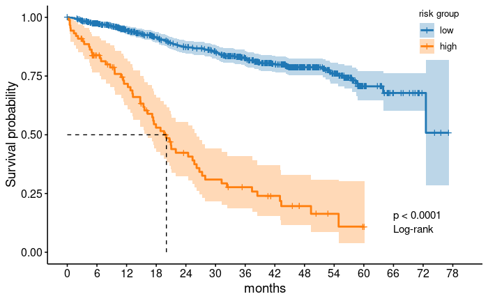

```r
km_plot
```

```r
top_lhs <- plot_grid(gmm2e_plot, NULL, ncol=1, rel_heights = c(3,1))
top_row5 <- plot_grid(top_lhs, NULL, km_plot$plot, labels = c('A','','B'), label_size = 12, ncol=3, rel_widths = c(1,0.2,2))
top_title <- ggdraw() + draw_label("CoMMpass derivation data", fontface='bold')
top_title_lj <- plot_grid(top_title, NULL, ncol=2, rel_widths =c(0.3,0.7))
top_row5_wt <- plot_grid(top_title_lj, top_row5, ncol=1, rel_heights=c(0.12, 1))
bottom_lhs <- plot_grid(gse2658_srs_histo, NULL, ncol=1, rel_heights = c(3,1))
bottom_row5 <- plot_grid(bottom_lhs, NULL, gse2658_cb_cthresh_kmplt$plot,
                         labels = c('C','','D'), label_size = 12, ncol=3, rel_widths = c(1,0.15,2))
bottom_title <- ggdraw() + draw_label("GSE2658 replication data", fontface='bold')
bottom_title_lj <- plot_grid(bottom_title, NULL, ncol=2, rel_widths =c(0.285,0.715))
bottom_row5_wt <- plot_grid(bottom_title_lj, bottom_row5, ncol=1, rel_heights=c(0.12, 1))
all_plots5 <- plot_grid(top_row5_wt, bottom_row5_wt, ncol=1)
```

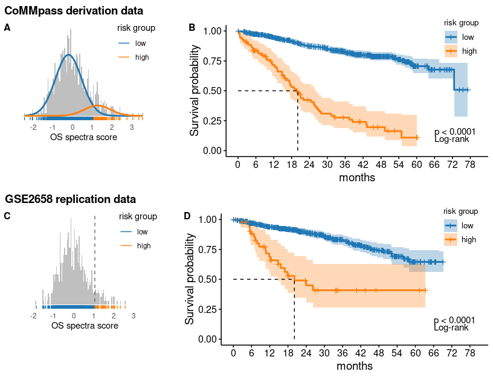

```r
all_plots5
```

```r
ggsave(filename="commpass_GSE2658_OS_gmm_km_plots_20220712.pdf", plot=all_plots5,
       device="pdf", width=8.5, height=6.5, units="in")
```